# Valuacion de Instrumentos

Diego

2024-12-16

# Valuacion de Bonos Cuponados

Tomando la serie de tasas diarias de la TIIE, obtenidas de Banxico, estos son los parametros del modelo de vasicek:

```
##                        alpha       r_e      sigma     logL
## iteraciones:  10000 19.99413 0.1093097 0.01694047 1024.929
```

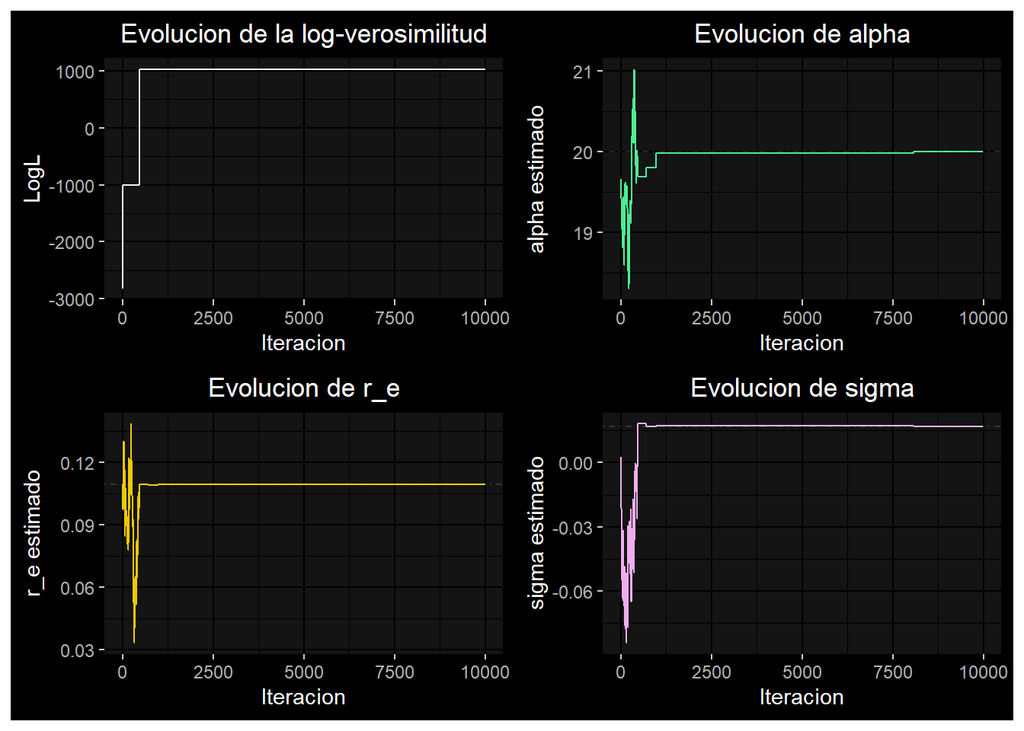

A continuacion, simularemos trayectorias bajo el modelo de Vasicek con los parametros que acabamos de estimar para nuestro conjunto de datos. Simularemos a un plazo de 60 dias;

3. ```
   Despues simularemos 50 trayectorias con 12 pasos por dia, i.e. un paso cada 2 horas
   ```

4. ```
   Al final simulamos 500 trayectorias con 48 pasos por dia, i.e. un paso cada 30 minutos
   ```

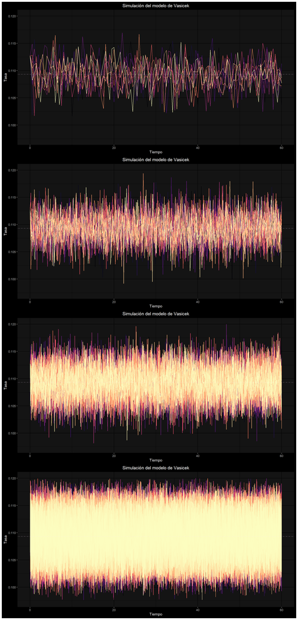

Observese que en la ultima estamos simulando $500 \cdot 60 \cdot 48 \, = \, 1,440,000$ datos.

# Valuacion de un Bono

### ¿Que es un bono cuponado?

Es un instrumento de deuda emitido por una entidad (gobierno, empresa u organismo) que paga periódicamente al inversor un pago de intereses por medio de cupones durante la vida del bono, hasta su fecha de vencimiento, momento en el que también se devuelve el capital invertido.

En otras palabras, el bono cupónado es un préstamo que el inversor otorga al emisor a cambio de pagos periódicos de intereses (cupones) y el reembolso del valor nominal al vencimiento.

### ¿Como usaremos el Modelo de Vasicek?

Supongamos que queremos valuar un bono con vencimiento a 2 meses, con los siguientes cupones quincenales: $(100,75,50,25)

Aprovechando las ultimas 500 simulaciones del modelo de vasicek convenientemente realizadas a 2 meses, la media y los intervalos de confianza muestrales al 95%, 90% y 85% respectivamente son:

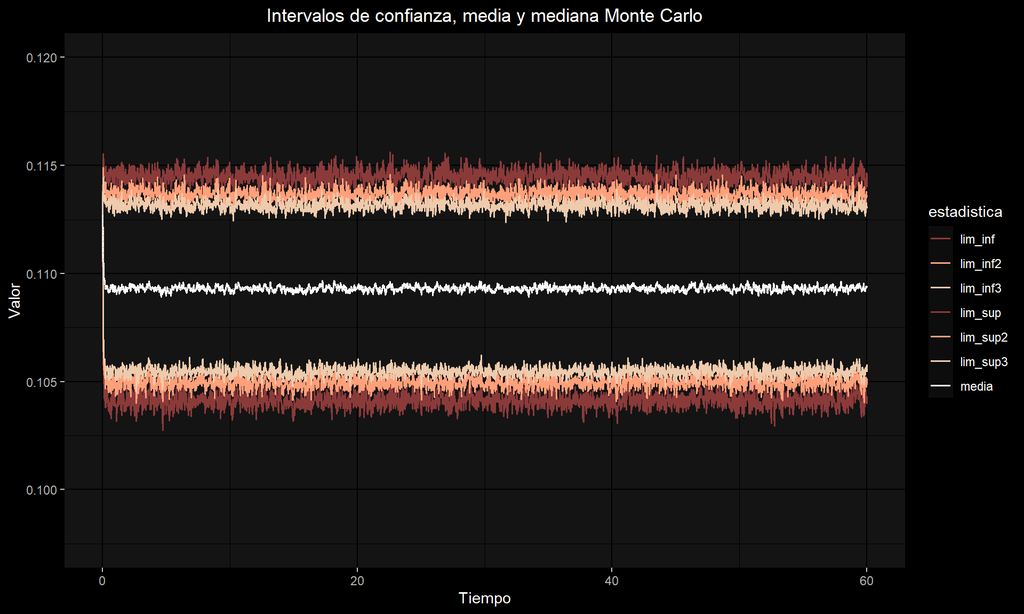

Extraeremos de ahi, la media y los intervalos de confianza en los 4 tiempos de valuacion del bono. Y aplicaremos la formula de valuacion siguiente, en donde cuando sustituyamos las tasas de descuento con las medias de la simulacion vasicek tendremos la tasa con la que traeremos a valor presente cada cupon y cuando sustituyamos los tasas de los intervalos de confianza de la simulacion vasicek, obtendremos intervalos de confianza para la valuacion del bono.

$$P \, = \, \frac{F}{(1+r_n)^n} \, + \,\sum_{t=1}^n \frac{C_t}{(1+r_t)^t}$$

donde F es el valor nominal y $C_t$ los cupones al tiempo t, $r_t$ las tasas al tiempo t y n el numero de cupones.

El valor Presente de dicho bono y los intervalos de confianza para este son:

| valor_presente |
| --- |
| 1230.701 |

```
## [1] "El intervalo al 95% de confianza es: ( $ 1229.92 , $ 1231.6 )"
```

```
## [1] "El intervalo al 90% de confianza es: ( $ 1230 , $ 1231.45 )"
```

```
## [1] "El intervalo al 85% de confianza es: ( $ 1230.09 , $ 1231.35 )"
```

Observese que los intervalos estan alrededor del estimador puntual del precio del bono y son de una longitud muy pequeña, por lo que son muy precisos con un alto nivel de confianza.